# Common microbiota analysis workflow using RIVM-Toolbox

Comparison of gut microbiota in older adults with and without ILI

Sudarshan A. Shetty

Mon Oct 18 11:52:15 2021

In this workflow, we demonstrate the use of RIVM-toolbox for common microbiome data analytics. We use the data from Fuentes S, et al. (2021) Associations of faecal microbiota with influenza-like illness in participants aged 60 years or older: an observational study. The Lancet Healthy Longevity, 2(1):e13-23.

# Setup

Initiate the analysis by loading the RIVM-Toolbox ( *biomeUtils*, *biomeViz* and *biomeStats*) and other handy external R packages.

## Packages

```r
# RIVM toolbox
library(biomeUtils)
library(biomeViz)
library(biomeStats)
# External
library(ggplot2)
library(patchwork)
library(dplyr)
library(microbiome)
library(ggsignif)
```

## Theme

Theme for data visualization.

```r
## change global theme settings (for all following plots)
theme_set(theme_biomViz(base_size = 12))
```

## Data

Load the example data.

```r
ps <- FuentesIliGutData
```

```r
# Check main comparison variable.
ps %>% getSampleTibble() %>%
  dplyr::count(ILI)
```

```
## # A tibble: 3 x 2
##   ILI       n
##   <fct> <int>
## 1 C       184
## 2 L1      213
## 3 L2      192
```

There are 184 controls, 213 ILI samples from visit-1 and 192 ILI samples after recovery visit-2.

# QC

Before starting detailed analysis, it is important to check and explore the data.  
Here, we explore basic sample and ASVs features.

```r
qc_Data <- calculateQC(ps)
qc_Data
```

```
## $SampleQC
## # A tibble: 589 x 4
##    Samples   sample_total_taxa sample_total_reads number_taxa_account_fifty_per~
##    <chr>                 <dbl>              <dbl>                          <int>
##  1 sample_1                259              15237                             11
##  2 sample_2                291              18970                             16
##  3 sample_3                336              21161                             16
##  4 sample_4                355              17754                             20
##  5 sample_5                300              25724                             11
##  6 sample_6                374              33815                             14
##  7 sample_7                251              13810                             15
##  8 sample_8                273              22730                             15
##  9 sample_9                279              22706                             15
## 10 sample_10               219              15521                              9
## # ... with 579 more rows
##
## $TaxaQC
## # A tibble: 905 x 9
##    taxa    taxa_counts taxa_mean_counts taxa_stdev_counts taxa_cv taxa_rank
##    <chr>         <dbl>            <dbl>             <dbl>   <dbl>     <dbl>
##  1 ASV302        13913           23.6               47.3     2.00     648
##  2 ASV636         4063            6.90              27.4     3.97     462
##  3 ASV500         6223           10.6               45.0     4.26     535
##  4 ASV7         784128         1331.              1652.      1.24     899
##  5 ASV2617         311            0.528              1.50    2.84      45
##  6 ASV148        40396           68.6              224.      3.26     765
##  7 ASV196        24796           42.1              137.      3.26     724
##  8 ASV2699         294            0.499              1.81    3.63      40.5
##  9 ASV109        60088          102.               303.      2.97     798
## 10 ASV1472         907            1.54               3.62    2.35     229
## # ... with 895 more rows, and 3 more variables: taxa_dectected_samples <dbl>,
## #   taxa_prevalence <dbl>, percent_of_total <dbl>
```

## Samples

We would like to check if there is some association between sequencing depth with number of ASVs we detect.

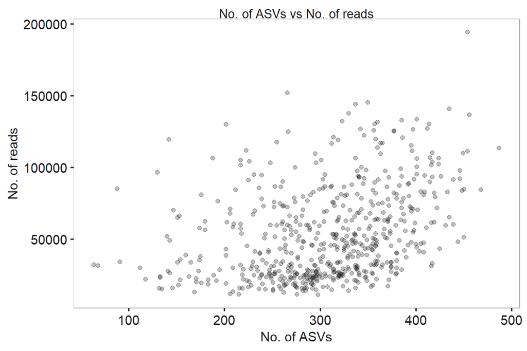

```r
sample_qc <- qc_Data$SampleQC

sample_qc %>%
  ggplot(aes(sample_total_taxa, sample_total_reads)) +
  geom_point(alpha=0.25) +
  labs(x="No. of ASVs", y = "No. of reads",
       subtitle = "No. of ASVs vs No. of reads")
```

## Taxa

Next we check some features of ASVs.

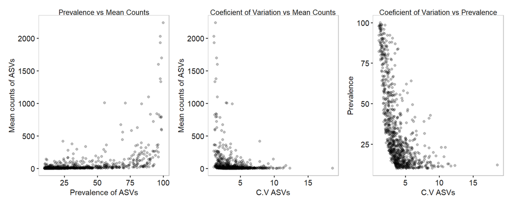

```r
taxa_qc <- qc_Data$TaxaQC

p1 <- taxa_qc %>%
  ggplot(aes(taxa_prevalence , taxa_mean_counts)) +
  geom_point(alpha=0.25) +
  labs(x = "Prevalence of ASVs", y = "Mean counts of ASVs",
       subtitle = "Prevalence vs Mean Counts")

p2 <- taxa_qc %>%
  ggplot(aes(taxa_cv , taxa_mean_counts)) +
  geom_point(alpha=0.25) +
  labs(x = "C.V ASVs", y = "Mean counts of ASVs",
       subtitle = "Coeficient of Variation vs Mean Counts")

p3 <- taxa_qc %>%
  ggplot(aes(taxa_cv , taxa_prevalence)) +
  geom_point(alpha=0.25) +
  labs(x = "C.V ASVs", y = "Prevalence",
       subtitle = "Coeficient of Variation vs Prevalence")

p1 | p2 | p3
```

These plots indicate a common feature of microbiome sequencing studies. ASVs with lower prevalence and abundances tend to have high variation (noisy ASVs). Several of the downstream analysis can be affected by these ASVs.

## Taxonomy

Check if the more abundance-prevalent ASVs have better taxonomic assignments.

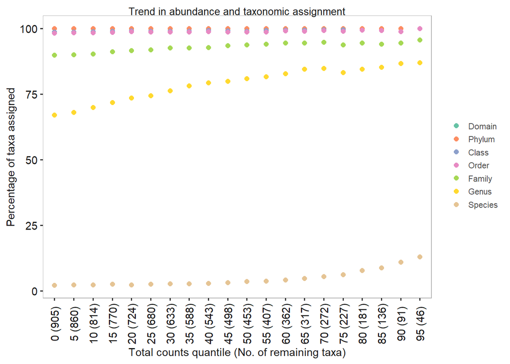

```r
p1 <- trendAbundanceAssignment(ps,
                              quantiles = seq(0, 95, by = 5),
                              plot=TRUE)
p1 + ggplot2::scale_colour_brewer("", palette = "Set2") +
    ggplot2::theme(axis.text.x = element_text(angle=90, vjust=0.5)) +
  labs(subtitle = "Trend in abundance and taxonomic assignment")
```

Check taxonomic assignments of ASVs.

```r
summarizeTaxonomicAssignments(ps)
```

```
## In Species column- 0 are ambigous assignments
```

```
## # A tibble: 7 x 4
##   Ranks   TaxonomyAssigned Total PrecentAssigned
##   <chr>              <int> <int>           <dbl>
## 1 Domain               905   905           100
## 2 Phylum               905   905           100
## 3 Class                894   905            98.8
## 4 Order                890   905            98.3
## 5 Family               814   905            89.9
## 6 Genus                606   905            67
## 7 Species               19   905             2.1
```

Now check the taxonomic assignments of ASVs.  
Useful to check this before aggregating at any level.

```r
polydf <- checkPolyphyletic(ps)
polydf
```

```
## # A tibble: 6 x 7
## # Groups:   Genus [3]
##   Domain   Phylum     Class      Order         Family          Genus   nfeatures
##   <chr>    <chr>      <chr>      <chr>         <chr>           <chr>       <int>
## 1 Bacteria Firmicutes Clostridia Clostridiales Lachnospiraceae Eubact~         2
## 2 Bacteria Firmicutes Clostridia Clostridiales Lachnospiraceae Clostr~         2
## 3 Bacteria Firmicutes Clostridia Clostridiales Lachnospiraceae Rumino~         2
## 4 Bacteria Firmicutes Clostridia Clostridiales Ruminococcaceae Rumino~         2
## 5 Bacteria Firmicutes Clostridia Clostridiales Eubacteriaceae  Eubact~         2
## 6 Bacteria Firmicutes Clostridia Clostridiales Ruminococcaceae Clostr~         2
```

We notice that *Eubacterium*, *Clostridium*, and *Ruminococcus* can be detected in different families. These taxa are known as polyphyletic and taxonomic resolution is unclear.

When taxonomic assignments are done following `dada2`, we have genus and species columns. These can be combine as `genus.species`.

```r
# Extract tax_table as tibble last three cols to demonstrate this
getTaxaTibble(ps)[,6:8]
```

```
## # A tibble: 905 x 3
##    Family          Genus                        Species
##    <chr>           <chr>                        <chr>
##  1 Lachnospiraceae Lachnospiraceae NC2004 group <NA>
##  2 Ruminococcaceae Ruminococcaceae UCG-013      <NA>
##  3 Ruminococcaceae <NA>                         <NA>
##  4 Lachnospiraceae Fusicatenibacter             saccharivorans
##  5 Ruminococcaceae <NA>                         <NA>
##  6 Ruminococcaceae <NA>                         <NA>
##  7 Lachnospiraceae Roseburia                    <NA>
##  8 Ruminococcaceae Butyricicoccus               <NA>
##  9 Rikenellaceae   Alistipes                    <NA>
## 10 Ruminococcaceae Oscillibacter                <NA>
## # ... with 895 more rows
```

Unite genus and species columns.

```r
ps <- uniteGenusSpeciesNames(ps)
# check
getTaxaTibble(ps)[,6:8]
```

```
## # A tibble: 905 x 3
##    Family          Genus                        Species
##    <chr>           <chr>                        <chr>
##  1 Lachnospiraceae Lachnospiraceae NC2004 group <NA>
##  2 Ruminococcaceae Ruminococcaceae UCG-013      <NA>
##  3 Ruminococcaceae <NA>                         <NA>
##  4 Lachnospiraceae Fusicatenibacter             Fusicatenibacter.saccharivorans
##  5 Ruminococcaceae <NA>                         <NA>
##  6 Ruminococcaceae <NA>                         <NA>
##  7 Lachnospiraceae Roseburia                    <NA>
##  8 Ruminococcaceae Butyricicoccus               <NA>
##  9 Rikenellaceae   Alistipes                    <NA>
## 10 Ruminococcaceae Oscillibacter                <NA>
## # ... with 895 more rows
```

## Sample

Similarly, one can combine two columns in sample data.

```r
# Extract tax_table as tibble last three cols to demonstrate this
getSampleTibble(ps)[,6:8]
```

```
## # A tibble: 589 x 3
##    sex     age ILI
##    <fct> <dbl> <fct>
##  1 M        72 C
##  2 F        71 C
##  3 F        66 C
##  4 F        70 C
##  5 M        69 L1
##  6 M        70 C
##  7 F        67 L1
##  8 M        81 C
##  9 F        78 C
## 10 F        68 L1
## # ... with 579 more rows
```

```r
ps <- uniteSampleColumn(ps,
                        "united.column", sex:age,
                        sep= ":",
                        remove = FALSE)
getSampleTibble(ps)[,6:8]
```

```
## # A tibble: 589 x 3
##    united.column sex     age
##    <chr>         <fct> <dbl>
##  1 M:72          M        72
##  2 F:71          F        71
##  3 F:66          F        66
##  4 F:70          F        70
##  5 M:69          M        69
##  6 M:70          M        70
##  7 F:67          F        67
##  8 M:81          M        81
##  9 F:78          F        78
## 10 F:68          F        68
## # ... with 579 more rows
```

## Taxa summary

Obtain a summary of ASVs by Phylum.

```r
getTaxaSummary(ps, rank="Phylum")
```

```
## # A tibble: 10 x 3
##    Phylum            Counts  Percent
##    <chr>              <int>    <dbl>
##  1 Firmicutes      23934274 76.3
##  2 Bacteroidetes    4845579 15.5
##  3 Proteobacteria    810484  2.58
##  4 Actinobacteria    630148  2.01
##  5 Verrucomicrobia   590273  1.88
##  6 Euryarchaeota     492906  1.57
##  7 Tenericutes        38848  0.124
##  8 Cyanobacteria       4694  0.0150
##  9 Lentisphaerae       4306  0.0137
## 10 Synergistetes       2775  0.00885
```

# Alpha diversity

We would like to compare phylogenetic diversity between these groups.

```r
ps.rare <- rarefy_even_depth(ps, rngseed = 1579)
```

```
## `set.seed(1579)` was used to initialize repeatable random subsampling.
```

```
## Please record this for your records so others can reproduce.
```

```
## Try `set.seed(1579); .Random.seed` for the full vector
```

```
## ...
```

```r
# all samples at specific depth
sample_sums(ps.rare)[1:10]
```

```
##  sample_1  sample_2  sample_3  sample_4  sample_5  sample_6  sample_7  sample_8
##     10975     10975     10975     10975     10975     10975     10975     10975
##  sample_9 sample_10
##     10975     10975
```

## Phylogenetic

Calculate phylogenetic diversity.

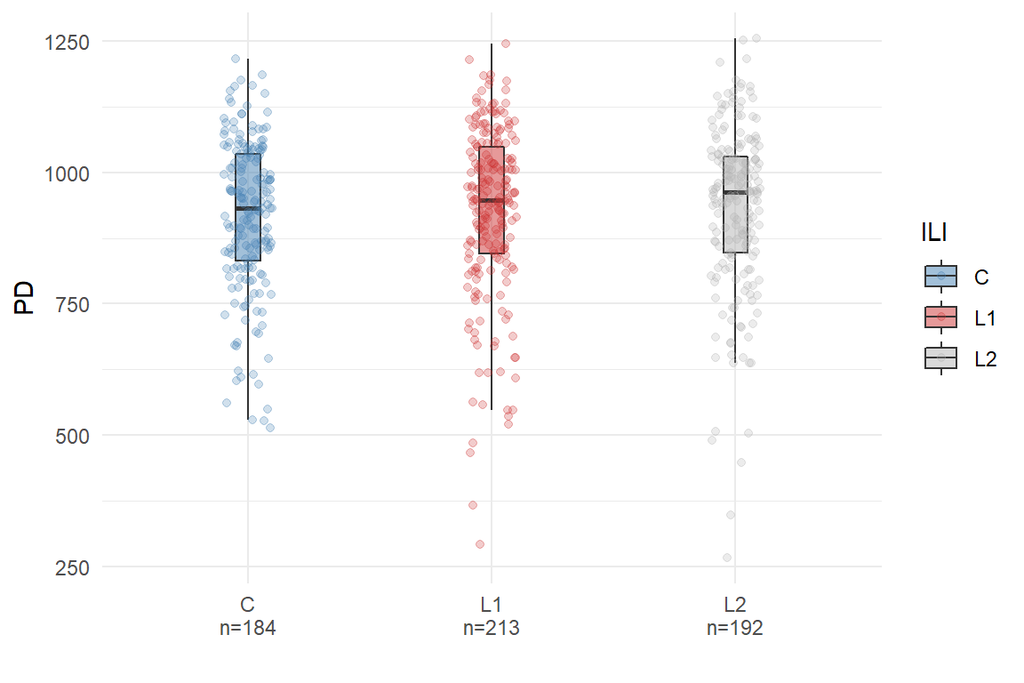

```r
# this will calcualte PD and add a new column in phyloseq object.
ps <- calculatePD(ps.rare, justDF = FALSE)

# we can visualize this with biomeViz::plotByGroup
biomeViz::plotByGroup(ps,
                      x.factor="ILI",
                      y.numeric = "PD") +
  geom_point(aes(color=ILI),
             position = position_jitter(width = 0.1),
             alpha=0.25) +
  scale_color_manual(values=c("steelblue", "brown3", "grey70")) +
  scale_fill_manual(values=c("steelblue", "brown3", "grey70"))
```

We can also see if there is any relationship between PD and age.

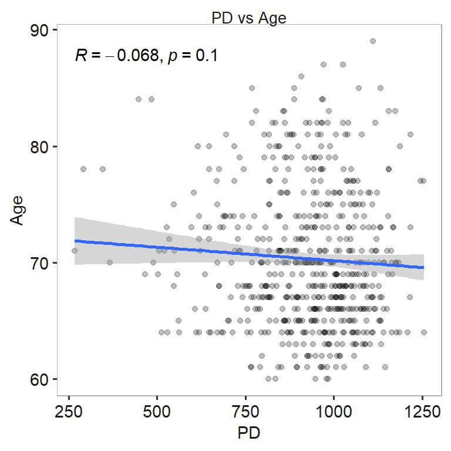

```r
getSampleTibble(ps) %>%
  ggplot(aes(PD, age)) +
  geom_point(alpha=0.25) +
  labs(x = "PD", y = "Age",
       subtitle = "PD vs Age") +
  ggpubr::stat_cor(method = "spearman") +
  geom_smooth(method = "lm")
```

## Shannon

We can also calculate other diversity indices from `microbiome` R pkg and add it to the our phyloseq data.  
For this we use `biomeUtils::mutateSampleData()` function in combination with `microbiome::diversity` function.

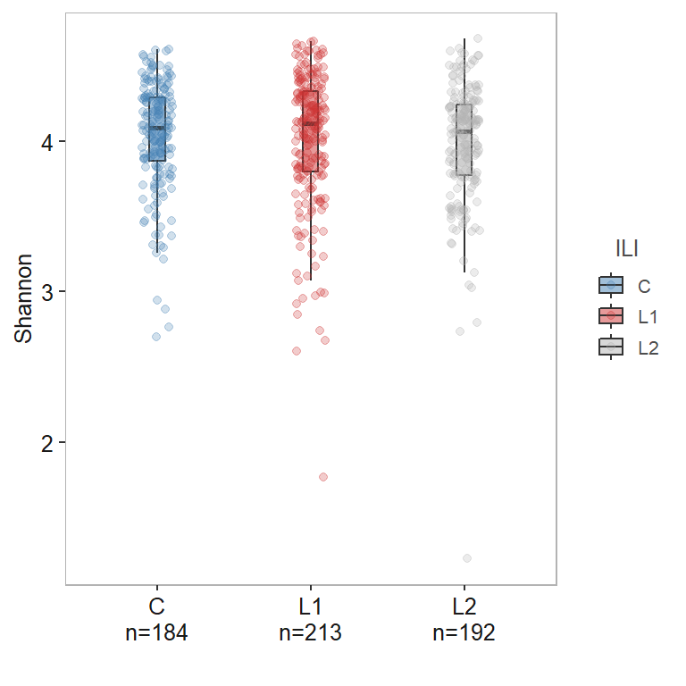

```r
ps <- mutateSampleData(ps,
                       Shannon = microbiome::diversity(ps, "shannon")[,1])
plotByGroup(ps,
            x.factor="ILI",
            y.numeric = "Shannon") +
  geom_point(aes(color=ILI),
             position = position_jitter(width = 0.1),
             alpha=0.25) +
  theme_biomViz() +
  scale_color_manual(values=c("steelblue", "brown3", "grey70")) +
  scale_fill_manual(values=c("steelblue", "brown3", "grey70"))
```

# Ordination

A Principal Coordinates Analysis for `phyloseq` object. To visualize similarities/dissimilarities between samples in 2D ordination. This function extends the `phyloseq` ordination plots to include taxa that correlate with chosen axis and plots them along with a side boxplot for comparing inter-sample variation within groups.

```r
library(biomeUtils)
library(dplyr)
library(ggside)
ps <- FuentesIliGutData %>%
  microbiome::transform("compositional") %>%
  mutateTaxaTable(FeatureID = taxa_names(FuentesIliGutData))
plotPCoA(x =ps,
         group_var = "ILI",
         ord_method = "PCoA",
         dist_method = "bray",
         seed = 1253,
         cor_method = "spearman",
         verbose = TRUE,
         padj_cutoff = 0.05,
         padj_method = "fdr",
         arrows = TRUE,
         label_col = "grey30",
         plot_centroids = TRUE,
         add_side_box = TRUE,
         axis_plot = c(1:2),
         point_shape = 21,  # point_shape
         point_alpha = 0.5) +
  theme_biomViz() +
  scale_color_manual(values = c("#3d6721", "#a86826", "#006c89")) +
  scale_fill_manual(values = c("#3d6721", "#a86826", "#006c89"))
```

[output not shown]

# Composition

## Abundant ASVs within Families

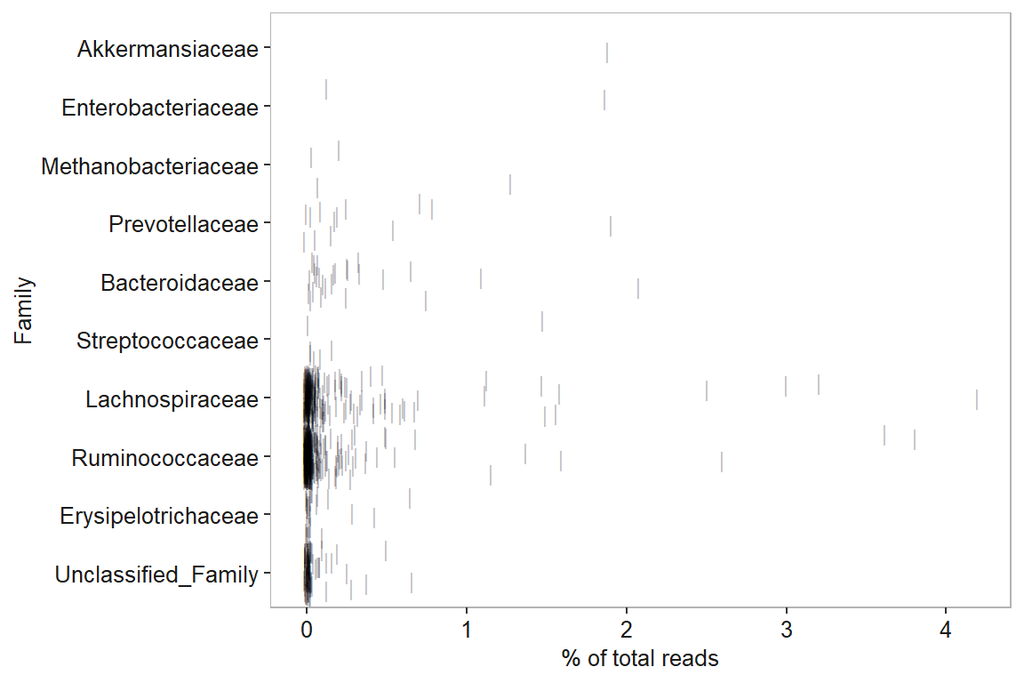

```r
plotTopAbundant(FuentesIliGutData,
                taxa_level = "Family",
                top=10,
                alpha = 0.25,
                shape = 124,
                color="black",
                fill = "black",
                size=3,
                width = 0.02) +
  theme_biomViz()
```

Most ASVs are within *Lachnospiraceae*, and *Ruminococcaceae*. These are know abundant families in human gut.

## Heatmap

Heatmap is useful to visualize patterns in abundances of taxa. Here, we compare abundance profiles of top 10 ASVs.

```
## tidyHeatmap says: (once per session) from release 1.2.3 the grouping labels have white background by default. To add color for one-ay grouping specify palette_grouping = list(c("red", "blue"))
```

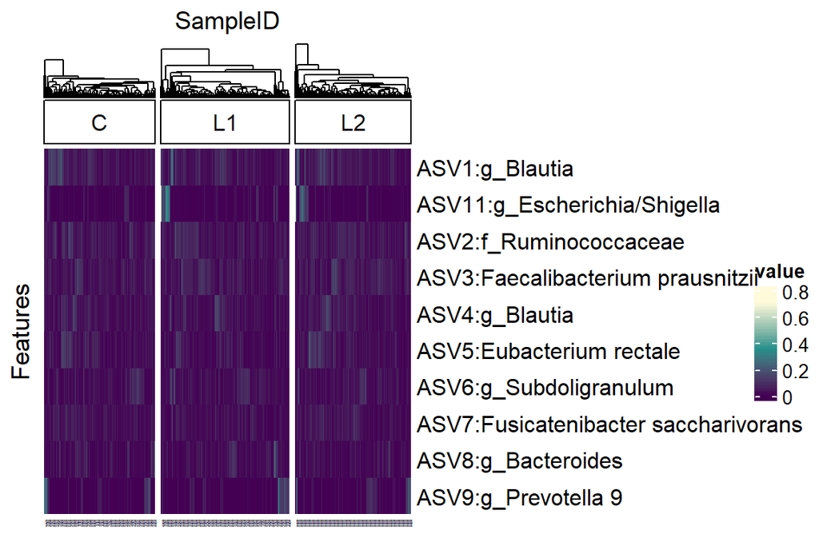

```r
ps.rel <- FuentesIliGutData %>%
         microbiome::transform("compositional")
select_taxa <- findTopTaxa(ps.rel, top= 10, method="mean")

plotTidyHeatmap(ps.rel, select_taxa = select_taxa,
                group_samples_by = "ILI",
                add_taxa_label = TRUE,
                cluster_rows = FALSE,
                .scale = "none",
                transform = NULL)
```

ASV11 *Escherichia/Shigella* is abundant in some samples from ILI group.

Check prevalence of top ASVs.

```r
prev_tib <- getPrevalence(ps.rel,
                          return_rank = c("Family", "Genus"),
                          return_taxa = select_taxa,
                          sort = TRUE)

prev_tib
```

```
##     Taxa prevalence             Family                Genus
## 1   ASV1  1.0000000    Lachnospiraceae              Blautia
## 2   ASV4  0.9881154    Lachnospiraceae              Blautia
## 3   ASV7  0.9813243    Lachnospiraceae     Fusicatenibacter
## 4   ASV6  0.9779287    Ruminococcaceae      Subdoligranulum
## 5   ASV2  0.9779287    Ruminococcaceae                 <NA>
## 6   ASV3  0.9779287    Ruminococcaceae     Faecalibacterium
## 7   ASV5  0.9626486    Lachnospiraceae          Eubacterium
## 8   ASV8  0.8879457     Bacteroidaceae          Bacteroides
## 9  ASV11  0.8353141 Enterobacteriaceae Escherichia/Shigella
## 10  ASV9  0.5551783     Prevotellaceae         Prevotella 9
```

## Compare abundances of genera

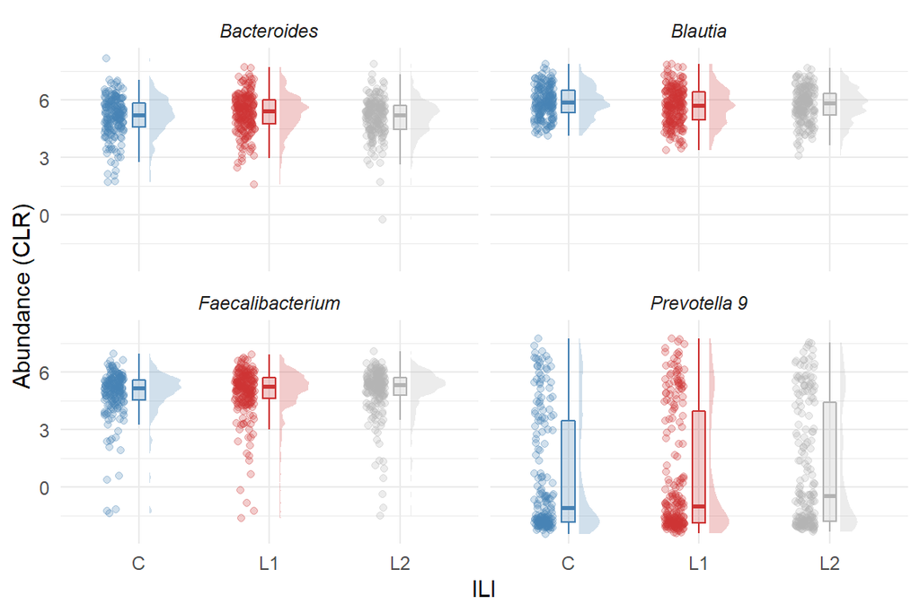

```r
ps.gen <- ps %>%
  microbiome::aggregate_taxa("Genus") %>%
  microbiome::transform("clr")

# Select taxa and group to compare

plotTaxaRaincloud(ps.gen,
                  taxa =c("Blautia", "Bacteroides", "Faecalibacterium","Prevotella 9"),
                  group_samples_by = "ILI",
                  opacity = 0.25,
                  shape_point = 21) +
  scale_color_manual(values=c("steelblue", "brown3", "grey70")) +
  scale_fill_manual(values=c("steelblue", "brown3", "grey70")) +
  labs(x="ILI", y = "Abundance (CLR)") +
  theme(strip.text = element_text(face="italic"))
```

# Common statistical tests

At present, Kruskal-Wallis and Wilcox Test are stably available in the `biomeStats` package.

## Kruskal-Wallis Test

When more than two groups are present, we use a non-parametric Kruskal-Wallis test to identify significantly different ASVs.

```r
ps.rel <- microbiome::aggregate_taxa(ps, "Genus") %>%
  microbiome::transform("compositional")
ps.rel <- core(ps.rel, detection=0.001, prevalence=50/100)

kw_results <- doKruskalWallisTest(ps.rel,
                                  sample_group = "ILI",
                                  adj_method = "BH",
                                  effect_size = TRUE) %>%
  dplyr::filter(p.adj <= 0.05)
print(kw_results)
```

```
## # A tibble: 4 x 12
##   variable        .y.       n statistic    df       p method  p.adj p.adj.signif
##   <chr>           <chr> <int>     <dbl> <int>   <dbl> <chr>   <dbl> <chr>
## 1 Parabacteroides value   589      14.9     2 5.75e-4 Krusk~ 0.0228 *
## 2 Bacteria_Firmi~ value   589      11.6     2 3.1 e-3 Krusk~ 0.0388 *
## 3 Fusicatenibact~ value   589      13.2     2 1.37e-3 Krusk~ 0.0228 *
## 4 Ruminococcus 1  value   589      13.4     2 1.25e-3 Krusk~ 0.0228 *
## # ... with 3 more variables: effsize <dbl>, effsize_method <chr>,
## #   magnitude <chr>
```

Four genera, *Parabacteroides*, *Fusicatenibacter*, *Ruminococcus 1* and *Eubacterium* (Lachnospiraceae) are significantly different.

Compare thier abundances between groups.

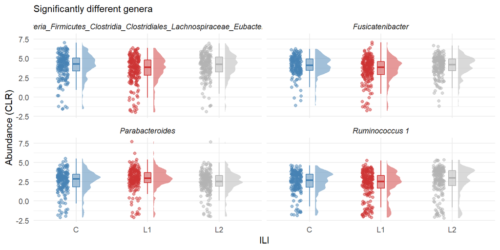

```r
# We use CLR abundances to visualize
ps.clr <- microbiome::aggregate_taxa(ps, "Genus") %>%
  microbiome::transform("clr")

plotTaxaRaincloud(ps.clr,
                  taxa =kw_results$variable,
                  group_samples_by = "ILI",
                  opacity = 0.5,
                  shape_point = 21) +
  scale_color_manual(values=c("steelblue", "brown3", "grey70")) +
  scale_fill_manual(values=c("steelblue", "brown3", "grey70")) +
  labs(x="ILI", y = "Abundance (CLR)", subtitle = "Significantly different genera") +
  theme(strip.text = element_text(face="italic"))
```

## Paired Wilcox Test

Within the ILI group, there are participants who had given samples at two visits. We use select these participants.

```r
two.vis.part <- filterSampleData(ps, ILI != "C") %>%
  getSampleTibble() %>%
  count(participant_id) %>%
  filter(n == 2) %>%
  pull(participant_id)

ps <- mutateSampleData(ps, two.visits = ifelse(participant_id %in%two.vis.part,
                                               "Yes", "No"))

ps.paired.ili <- filterSampleData(ps, two.visits == "Yes")

ps.paired.ili.rel <- microbiome::aggregate_taxa(ps.paired.ili, "Genus") %>%
  microbiome::transform("compositional")

ps.paired.ili.rel <- core(ps.paired.ili.rel, detection=0.001, prevalence=50/100)

wilcox_results <- doWilcoxTest(ps.paired.ili.rel,
                               sample_group = "ILI",
                               paired = TRUE,
                               adj_method = "BH",
                               alternative = "greater") %>%
                  dplyr::filter(p.adj <= 0.05)
wilcox_results
```

```
## # A tibble: 2 x 10
##   variable        .y.   group1 group2    n1    n2 statistic       p  p.adj p.adj.signif
##   <fct>           <chr> <chr>  <chr>  <int> <int>     <dbl>   <dbl>  <dbl> <chr>
## 1 Bacteroides     value L1     L2       192   192    11594. 0.00126 0.0302 *
## 2 Parabacteroides value L1     L2       192   192    11621  0.00112 0.0302 *
```

Compare their abundances between groups.  
*Bacteroides*

```r
# We use CLR abundances to visualize
ps.paired.ili.clr <- microbiome::aggregate_taxa(ps.paired.ili, "Genus") %>%
  microbiome::transform("compositional")
# raincloud
bac.ab.plot <- plotTaxaRaincloud(ps.paired.ili.clr,
                                 taxa = "Bacteroides",
                                 group_samples_by = "ILI",
                                 opacity = 0.5,
                                 shape_point = 21) +
  scale_color_manual(values=c("brown3", "grey70")) +
  scale_fill_manual(values=c("brown3", "grey70")) +
  labs(x="", y = "Relative abundance ", subtitle = "Bacteroides") +
  theme(strip.text = element_text(face="italic"),
        plot.subtitle = element_text(face="italic"))

# Prevalence
bac.prev.l1 <- microbiome::aggregate_taxa(ps.paired.ili, "Genus") %>%
  filterSampleData(ILI=="L1") %>%
  getPrevalence(return_taxa = "Bacteroides", return_rank = "Genus") %>%
  pull(prevalence)

bac.prev.l2 <- microbiome::aggregate_taxa(ps.paired.ili, "Genus") %>%
  filterSampleData(ILI=="L2") %>%
  getPrevalence(return_taxa = "Bacteroides", return_rank = "Genus") %>%
  pull(prevalence)

bac.tib <- tibble(Genus=c("Bacteroides","Bacteroides"),
              prev = c(bac.prev.l1,bac.prev.l2),
              group = c("L1", "L2"))

bac.prev.plot <- bac.tib %>%
  ggplot(aes(group, prev)) +
  geom_col(aes(fill=group), width = 0.5,
           alpha=0.5) +
  scale_fill_manual(values=c("brown3", "grey70")) +
  labs(x="", y = "", subtitle = "Prevalence") +
  scale_y_continuous(position = "right") +
  theme(legend.position = "none")
```

*Parabacteroides*

```r
parabac.ab.plot <- plotTaxaRaincloud(ps.paired.ili.clr,
                                 taxa = "Parabacteroides",
                                 group_samples_by = "ILI",
                                 opacity = 0.5,
                                 shape_point = 21) +
  scale_color_manual(values=c("brown3", "grey70")) +
  scale_fill_manual(values=c("brown3", "grey70")) +
  labs(x="", y = "Relative abundance ", subtitle = "Parabacteroides") +
  theme(strip.text = element_text(face="italic"),
        plot.subtitle = element_text(face="italic"))

# Prevalence
parbac.prev.l1 <- microbiome::aggregate_taxa(ps.paired.ili, "Genus") %>%
  filterSampleData(ILI=="L1") %>%
  getPrevalence(return_taxa = "Parabacteroides", return_rank = "Genus") %>%
  pull(prevalence)

parbac.prev.l2 <- microbiome::aggregate_taxa(ps.paired.ili, "Genus") %>%
  filterSampleData(ILI=="L2") %>%
  getPrevalence(return_taxa = "Parabacteroides", return_rank = "Genus") %>%
  pull(prevalence)

parabac.tib <- tibble(Genus=c("Parabacteroides","Parabacteroides"),
                      prev = c(parbac.prev.l1,parbac.prev.l2),
                      group = c("L1", "L2"))

parabac.tib.plot <- parabac.tib %>%
  ggplot(aes(group, prev)) +
  geom_col(aes(fill=group), width = 0.5,
           alpha=0.5) +
  scale_fill_manual(values=c("brown3", "grey70")) +
  labs(x="", y = "", subtitle = "Prevalence") +
  scale_y_continuous(position = "right") +
  theme(legend.position = "none")
```

### Adding p-value

To add p-values to the plot, we can use `ggsignif`.

```r
# get comparisons
comparsions.list <- as.character(unique(bac.ab.plot$data$ILI))

# bacteroides
get_pval_bac <- wilcox_results %>%
  filter(variable == "Bacteroides")

bac.ab.plot <- bac.ab.plot +
  ggsignif::geom_signif(
    comparisons = list(comparsions.list),
    y_position = max(bac.ab.plot$data$Abundance)+0.05, tip_length = 0.03, vjust = 0.2,
    annotation = get_pval_bac$p.adj.signif,
    color= "grey30",
    textsize = 3)

# parabacteroides
get_pval_parabac <- wilcox_results %>%
  filter(variable == "Parabacteroides")

parabac.ab.plot <- parabac.ab.plot +
  ggsignif::geom_signif(
    comparisons = list(comparsions.list),
    y_position = max(parabac.ab.plot$data$Abundance)+0.05, tip_length = 0.03, vjust = 0.2,
    annotation = get_pval_parabac$p.adj.signif,
    color= "grey30",
    textsize = 3)
```

Combine plots.

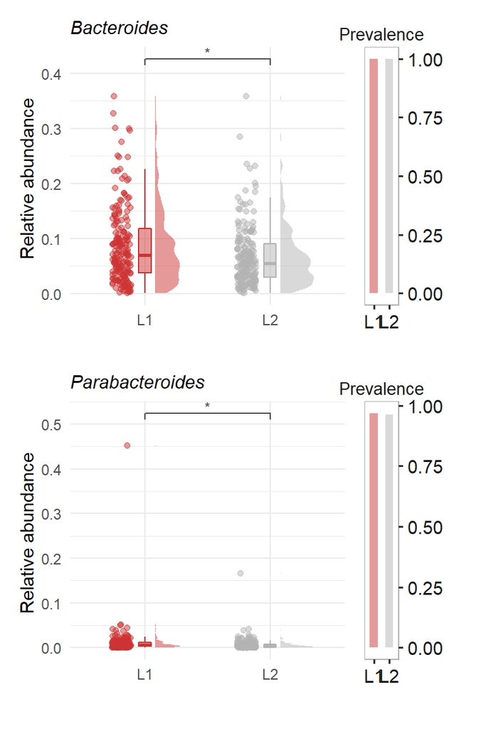

```r
 (bac.ab.plot + bac.prev.plot + plot_layout(widths = c(8,1)))/ (parabac.ab.plot + parabac.tib.plot + plot_layout(widths = c(8,1)))
```